# Class 1 methods 3

## Exercise 2

Compare the plotted quadratic fit to the linear fit

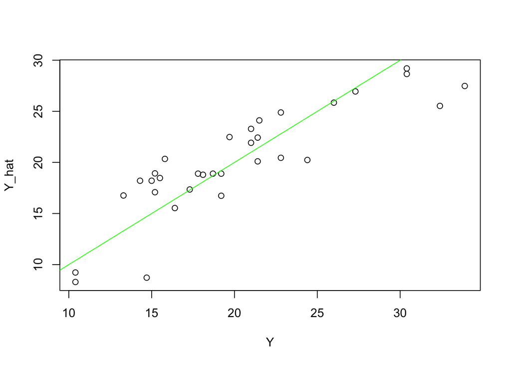

```r
plot(Y, Y_hat)
abline(a=0, b=1, col="green")
```

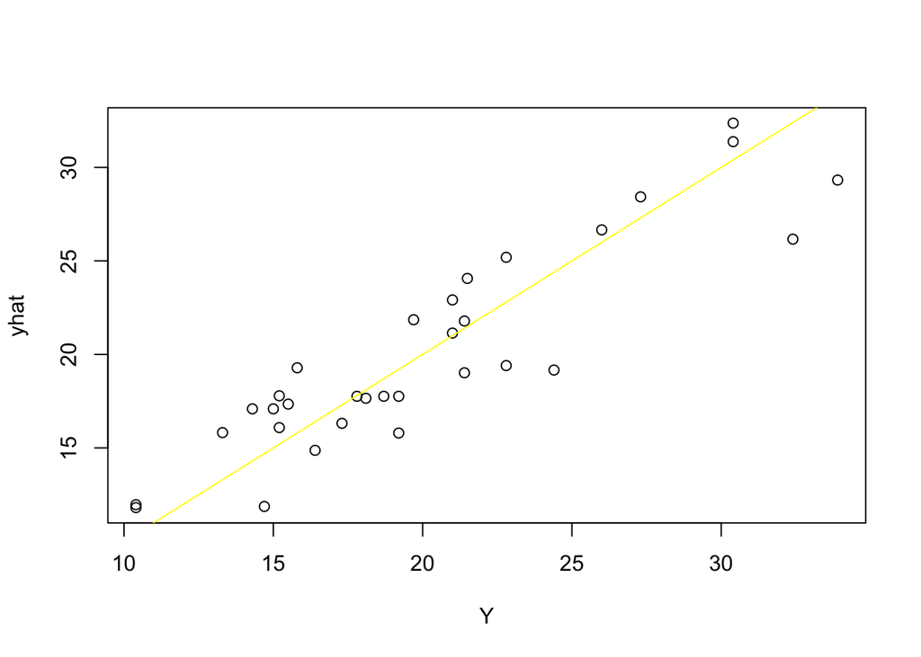

```r
plot(Y, yhat)
abline(a=0, b=1, col="yellow")
```

1. Which seems better?  
The quadratic (number 2) seems to catch the tendencies of the data a little bit better than the first one. This can be seen as the errors are more evenly distributed along the line in the quadratic plot.

2. calculate the sum of squared errors, (show the calculation based on $\epsilon$). Which fit has the lower sum?

```r
sum((Y-Y_hat)^2)
```

```
## [1] 278.3219
```

```r
sum((Y-yhat)^2)
```

```
## [1] 203.7454
```

```r
#sum((model$residuals)^2)
```

The sum of the squared errors is lower for the quadratic model, which means that it’s differences between observed values and predicted values are lower than the ones from the linear fit. Ergo the quadratic fit is better.

3. now make a cubic fit ($y = {\beta}_{3} x^3 + {\beta}_{2} x^2 + {\beta}_{1} x + {\beta}_{0}$) and compare it to the quadratic fit

```r
cubic_fit <- cbind( design_matrix, (mtcars$wt)^3)

#added cubic fit to the model in a new column
lm_cubic_compare <- lm(Y ~ design_matrix [,2] + design_matrix [,3] + cubic_fit [,4])
```

1. create a plot that illustrates $Y$ and $\hat{Y}$ for both the cubic and the quadratic fits (plot them in the same plot)

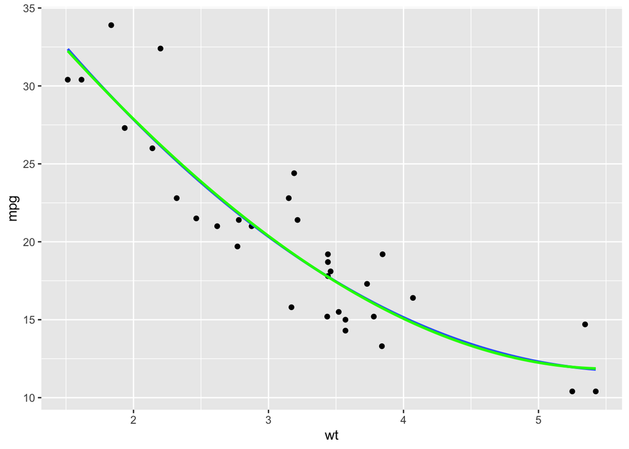

```r
both_plot <- ggplot(mtcars, aes(x = wt, y = mpg))+
  geom_point()+
  stat_smooth(method = "lm", formula = y ~ x + I(x^2), size = 1, se = FALSE)+
  stat_smooth(method = "lm", formula = y ~ x + I(x^2) + I(x^3), size = 1, color = "green", se = FALSE)
both_plot
```

ii. compare the sum of squared errors

```r
sum((Y-yhat)^2)
```

```
## [1] 203.7454
```

```r
sum((lm_cubic_compare$residuals)^2)
```

```
## [1] 203.6699
```

The cubic fit is a tiny bit lower and thereby better

3. what’s the estimated value of the “cubic” (${\beta}_3$) parameter?

```r
coef(lm_cubic_compare)
```

```
##        (Intercept) design_matrix[, 2] design_matrix[, 3]     cubic_fit[, 4]
##        48.40369623       -11.82597602         0.68937919         0.04593618
```

It’s a small number, so it doesn’t have great influence on the model. (0.04593)

4. bonus question: which summary statistic is the fitted value (*Intercept* or ${\beta}_0$ in $y = {\beta}_0$) below identical to?

```
##
## Call:
## lm(formula = mpg ~ 1, data = mtcars)
##
## Coefficients:
## (Intercept)
##       20.09
```

## Exercise 3

Doing a logistic regression - estimating the probability that a car has automatic transmission (0) or manual transmission (1) based on its weight

```r
data(mtcars)
logistic.model <- glm(formula= am ~ wt, data=mtcars, family='binomial')
```

Probabilities live on the range $(0, 1)$ - using the so-called logit function as a “link-function” we can map these onto the range $(-\infty, \infty)$, i.e. the real numbers.

What we model in this case is: $Pr(y = 1) = logit^{-1}(X \beta)$, i.e. the probability of a car having manual transmission, given its weight. $X \beta$ is called the linear predictor; compare with $Y = X \beta + \epsilon$ It is helpful to define the logit function and its inverse function for the following:

```r
logit <-     function(x) log(x / (1 - x))
inv.logit <- function(x) exp(x) / (1 + exp(x))
```

1. plot the fitted values for **logistic.model**:
   1. what is the relation between the **linear.predictors** and the **fitted_values** of the **logistic.model** object?
2. plot the logistic function, you’ve estimated based on your $\hat{\beta}$, (not just the fitted values). Use an *xlim* of (0, 7)
   1. what’s the interpretation of the estimated $\hat{\beta}_0$ (the *Intercept*)
   2. calculate the estimated probability that the Pontiac Firebird has automatic transmission, given its weight
   3. bonus question - plot the logistic function and highlight all the cars where we guessed wrongly, if we used the following “quantizer” function:

$$\begin{equation}
transmission_{guess}=
\begin{cases}
1 (manual), & \text{if}\ PR(y = 1) ≥ 0.5 \\
0 (automatic), & \text{otherwise}
\end{cases}
\end{equation}$$

3. plot quadratic fit alongside linear fit
   1. judging visually, does adding a quadratic term make a difference?
   2. check the details in the help of the AIC function - which of the models provide the better fit according to the AIC values and the residual deviance respectively?
   3. in your own words, why might it be good to penalise a model like the quadratic model, we just fitted.